# Assignment 1

Mason Wong (SID:470408326)

9/9/2021

# Executive summary

## Process summary and results

**Our Process and results**

Given the raw data set `AHS11biomedical.csv` we began by first of all cleaning the data. This mainly consisted of: cleaning the variable names, obtaining the types of our variables and understanding what each one of them meant. The script `clean_data.R` does this and from the script we obtain the `.Rdata files`: `proc_biom`, `types_biom` and `dict_biom`. We go further into what each of these mean in the **our data** section below.

Now to talk about our process…

## Summary of final data set and potential research questions

The final data set we ended up with was called `clean_biom`. There were 3199 observations and 27 variables. The variables which we have in our data set are:

```r
# Load in the data from the Rdata objects
load(here::here("tech_data.Rdata"))
variable_names = c("ABSPID", "BMISC", "AGEC", "SMSBC", "COBBC", "FEMLSBC", "PHDKGWBC",
    "PHDCMHBC", "EXLWTBC", "PHDCMWBC", "SF2SA1QN", "INCDEC", "ADTOTSE", "BDYMSQ04",
    "DIASTOL", "DIETQ12", "DIETQ14", "DIETQ5", "DIETQ8", "SABDYMS", "SEX", "SLPTIME",
    "SMKDAILY", "SMKSTAT", "SYSTOL", "BIORESPC", "GGTNTR")
types_biom %>%
    select(variable_name, description) %>%
    filter(variable_name %in% variable_names) %>%
    DT::datatable(., rownames = FALSE, options = list(columnDefs = list(list(className = "dt-center",
        targets = 0:1)), pageLength = 9))
```

| variable_name | description |
| --- | --- |
| ABSPID | Aus Bureau Stat Person Identification number |
| BMISC | Body mass index (BMI) |
| AGEC | Age of person (y) |
| SMSBC | Social marital status |
| COBBC | Country of birth |
| FEMLSBC | Female life stages |
| PHDKGWBC | Measured weight (kg) |
| PHDCMHBC | Measured height (cm) |
| EXLWTBC | Total mins undertaken physical activity in last week |
| PHDCMWBC | Measured waist circumference (cm) |

[output cut: 17 more lines]

Some potential research questions we could answer with the data we have are:

1. How does BMI (`BMISC`), physical exercise (`EXLWTBC` and `ADTOTSE`), diet (`DIETQ5`, `DIETQ8`, `DIETQ12` and `DIETQ14`) and lifestyle (`SLPTIME`) affect the present of high blood pressure (`DIASTOL` and `SYSTOL`) in individuals over the age of 40 (`AGEC`)?
2. What role does diet restriction (`DIETQ5`, `DIETQ8`, `DIETQ12`, `DIETQ14`, `BDYMSQ04`) and biological sex (`SEX`) play in the physical (`BMISC`) and mental (`SABDYMS`) health of an individual?
3. Are social factors like socio-economic status, income and nationality (`SF2SA1QN`, `INCDEC` and `COBBC`) risk factors for high blood pressure (`DIASTOL` and `SYSTOL`)?

# Our Data

The data which we will be looking at is data from the `AHS11biomedical.csv`. Now, as we have already cleaned the data (using the `CleanData.rmd` which generated `tech_data.Rdata`) in this report we will be looking at **three** main data frames we have obtained from the `tech_data.Rdata` file. They are: `proc_biom`, `types_biom`, `dict_biom`. Click on the following tabs in this section to learn more about them.

## proc_biom

This is essentially the raw data except all the categorical variables are explicitly converted to the `factor` data type (for R processing). We have also taken the liberty of replacing all values with `NA` if they were invalid, missing or not present.

```r
proc_biom %>%
    dplyr::select(1:8) %>%
    head(5) %>%
    DT::datatable() %>%
    DT::formatRound(columns = c("BMISC", "PHDKGWBC", "PHDCMHBC"), digits = 2)
```

|  | ABSPID | BMISC | AGEC | SMSBC | COBBC | FEMLSBC | PHDKGWBC | PHDCMHBC |
| --- | --- | --- | --- | --- | --- | --- | --- | --- |
| 1 | NPA11B10000011 | 20.90999985 | 46 | 1 | 1 | 6 | 60.5 | 170.1000061 |
| 2 | NPA11B10000021 | 29.75 | 77 | 1 | 3 |  | 96.69999695 | 180.3000031 |
| 3 | NPA11B10000031 | 24.37999916 | 55 | 1 | 1 | 4 | 63.20000076 | 161 |
| 4 | NPA11B10000041 | 21.36000061 | 59 | 1 | 1 | 5 | 57.09999847 | 163.5 |
| 5 | NPA11B10000051 |  | 29 | 1 | 1 | 2 |  |  |

Figure 1: proc_biom shown for the first 8 variables and the first 5 observations

## types_biom

This data frame gives us a description of each of the variables (alongside any extra information). The type information for each variable is also given.

```r
DT::datatable(types_biom, options = list(pageLength = 5))
```

|  | variable_name | description | extra | variable_type |
| --- | --- | --- | --- | --- |
| 1 | ABSPID | Aus Bureau Stat Person Identification number |  | string |
| 2 | ABSHID | Aus Bureau Stat Household Identification number |  | string |
| 3 | BMISC | Body mass index (BMI) |  | continuous |
| 4 | AGEC | Age of person (y) |  | continuous |
| 5 | SMSBC | Social marital status | All persons in household 15 years and over | categorical |
| 6 | COBBC | Country of birth | All persons | categorical |
| 7 | FEMLSBC | Female life stages | Females aged 10 years and over | categorical |
| 8 | PHDKGWBC | Measured weight (kg) |  | continuous |
| 9 | PHDCMHBC | Measured height (cm) |  | continuous |
| 10 | EXLWTBC | Total mins undertaken physical activity in last week |  | continuous |

[output cut: 45 more lines]

Figure 2: types_biom shown for 5 observations at a time

## dict_biom

Like `types_biom` this gives us a description of each of the variables. Unlike `types_biom`, it provides further information by explaining what each of the levels for each variable means.

```r
DT::datatable(dict_biom, options = list(pageLength = 5))
```

|  | variable_name | description | extra |
| --- | --- | --- | --- |
| 1 | ABSPID | Aus Bureau Stat Person Identification number |  |
| 2 | ABSHID | Aus Bureau Stat Household Identification number |  |
| 3 | BMISC | Body mass index (BMI) |  |
| 4 | BMISC | 0. Not applicable |  |
| 5 | BMISC | Greater than 0. but less than 97. Continuous - two decimal |  |
| 6 | BMISC | 98. Measurement not taken - refusal |  |
| 7 | BMISC | 99. Measurement not taken - other reason |  |
| 8 | AGEC | Age of person (y) |  |
| 9 | AGEC | 0. to 98. Continuous |  |
| 10 | AGEC | 99. 99 years and over |  |

[output cut: 355 more lines]

Figure 3: dict_biom shown for 5 observations at a time

# Exploratory Data Analysis

## Outliers

```r
# total number of observations:
n_tot = proc_biom %>%
    nrow()

# the following variables have outliers
n_tot = proc_biom %>%
    select(BMISC) %>%
    nrow()
bmisc = ggplot(data = proc_biom) + geom_boxplot(mapping = aes(x = BMISC), outlier.size = 4)
prop_bmisc = (proc_biom %>%
    filter(BMISC > 40) %>%
    nrow())/n_tot * 100

n_tot = proc_biom %>%
    select(PHDCMHBC) %>%
    nrow()
phdcmhbc = ggplot(data = proc_biom) + geom_boxplot(mapping = aes(x = PHDCMHBC))
prop_phdcmhbc = ((proc_biom %>%
    filter(PHDCMHBC > 200) %>%
    nrow()) + (proc_biom %>%
    filter(PHDCMHBC < 130) %>%
    nrow()))/n_tot * 100

n_tot = proc_biom %>%
    select(PHDCMWBC) %>%
    nrow()
phdcmwbc = ggplot(data = proc_biom) + geom_boxplot(mapping = aes(x = PHDCMWBC))
prop_phdcmwbc = (proc_biom %>%
    filter(PHDCMWBC > 135) %>%
    nrow())/n_tot * 100

n_tot = proc_biom %>%
    select(DIASTOL) %>%
    nrow()
diastol = ggplot(data = proc_biom) + geom_boxplot(mapping = aes(x = DIASTOL))
prop_diastol = ((proc_biom %>%
    filter(DIASTOL < 45) %>%
    nrow()) + (proc_biom %>%
    filter(DIASTOL > 102) %>%
    nrow()))/n_tot * 100

n_tot = proc_biom %>%
    select(SLPTIME) %>%
    nrow()
slptime = ggplot(data = proc_biom) + geom_boxplot(mapping = aes(x = SLPTIME))
prop_slptime = ((proc_biom %>%
    filter(SLPTIME < 225) %>%
    nrow()) + (proc_biom %>%
    filter(SLPTIME > 769) %>%
    nrow()))/n_tot * 100

n_tot = proc_biom %>%
    select(SYSTOL) %>%
    nrow()
systol = ggplot(data = proc_biom) + geom_boxplot(mapping = aes(x = SYSTOL))
prop_systol = ((proc_biom %>%
    filter(SYSTOL < 69) %>%
    nrow()) + (proc_biom %>%
    filter(SYSTOL > 169) %>%
    nrow()))/n_tot * 100
```

We firstly look for outliers in our numerical variables. We see that out of the 9 numerical variables, 6 of them contain outlier observations. From the boxplots below we can roughly see that for the following variables:

- **BMISC (Body mass index)**: There are approximately 2% observations which are outliers
- **PHDCMHBC (height in cm)**: There are approximately 7.5% observations which are outliers
- **PHDCMWBC (waist circumference in cm)**: There are approximately 0.6% observations which are outliers
- **DIASTOL (diastolilc blood pressure)**: There are approximately 6.8% observations which are outliers
- **SLPTIME (sleep duration in minutes prior to interview)**: There are approximately 1.8% observations which are outliers
- **SYSTOL (systolic blood pressure)**: There are approximately 7.1% observations which are outliers

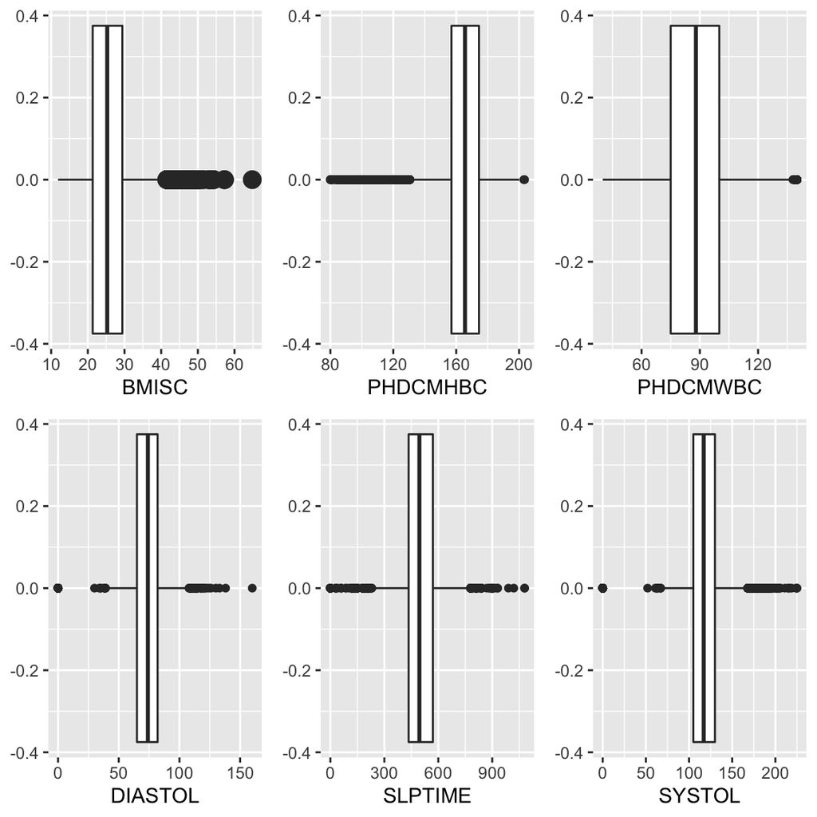

```r
# arrange them on a 3x2 grid
grid.arrange(bmisc, phdcmhbc, phdcmwbc, diastol, slptime, systol, ncol = 3, nrow = 2)
```

Click the next tab to see the next subsection on **logical inconsistencies**

## Logical inconsistencies

Some logical inconsistencies which we can see with the variables in the data are:

```r
n_tot = proc_biom %>%
    select(EXLWTBC) %>%
    nrow()
exlwtbc_prop = (proc_biom %>%
    filter(EXLWTBC == 9996 | EXLWTBC == 9999) %>%
    nrow())/n_tot * 100
exlwtbc_hist = ggplot(data = proc_biom) + geom_histogram(mapping = aes(x = EXLWTBC)) +
    theme(axis.text.x = element_text(angle = 45, hjust = 1))


n_tot = proc_biom %>%
    select(EXLWMBC) %>%
    nrow()
exlwmbc_prop = (proc_biom %>%
    filter(EXLWMBC == 9996 | EXLWMBC == 9999) %>%
    nrow())/n_tot * 100
exlwmbc_hist = ggplot(data = proc_biom) + geom_histogram(mapping = aes(x = EXLWMBC)) +
    theme(axis.text.x = element_text(angle = 45, hjust = 1))


n_tot = proc_biom %>%
    select(EXLWVBC) %>%
    nrow()
exlwvbc_prop = (proc_biom %>%
    filter(EXLWVBC == 9996 | EXLWVBC == 9999) %>%
    nrow())/n_tot * 100
exlwvbc_hist = ggplot(data = proc_biom) + geom_histogram(mapping = aes(x = EXLWVBC)) +
    theme(axis.text.x = element_text(angle = 45, hjust = 1))
```

- **The exercise variables** : For the exercise variables `EXLWTBC`, `EXLWMBC` and `EXLWVBC` (corresponding to **total exercise**, **moderate exercise** and **vigorous exercise** in the past week) there is a logical inconsistency as there are values which suggest an individual has exercised for 6.9 days straight (corresponding to values of 9996 and 9999). It seems that more likely since 9996 and 9999 are values which are present with such high frequency (and precisely those two values), it may be the case that these should have been values which had another meaning in the data dictionary. We can see these logical inconsistencies in the following histograms:
  - Approximately for `EXLWTBC` there are 23.25% of observations which are not logically consistent
  - Approximately for `EXLWMBC` there are 22.46% of observations which are not logically consistent
  - Approximately for `EXLWVBC` there are 22.53% of observations which are not logically consistent

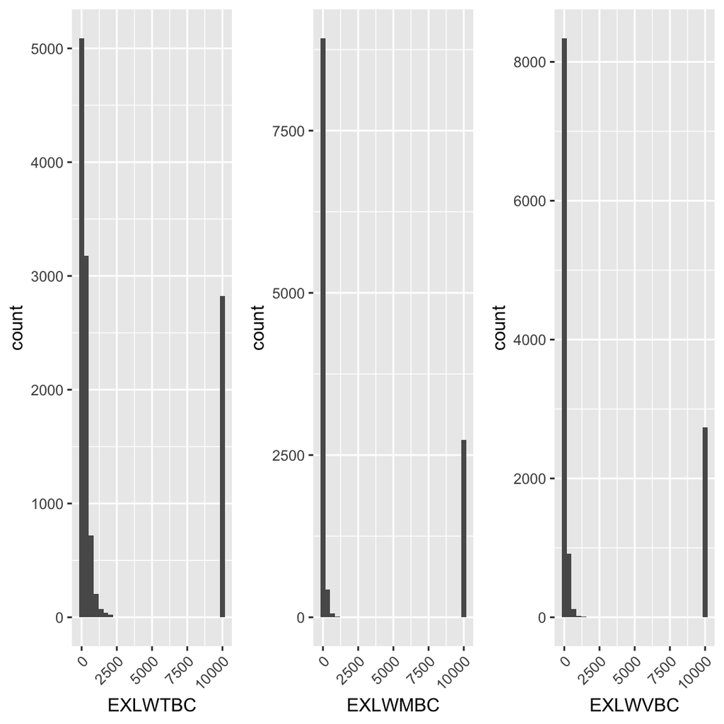

```r
grid.arrange(exlwtbc_hist, exlwmbc_hist, exlwvbc_hist, ncol = 3)
```

- For the exercise variables `EXLWTBC`, `EXLWMBC` and `EXLWVBC` it seems appropriate to encode the values corresponding to 9996 and 9999 as `NA` until more information about the levels of these variables is given.

```r
proc_biom = proc_biom %>%
    mutate(EXLWTBC = case_when(EXLWTBC == 9996 ~ as.numeric(NA), EXLWTBC == 9999 ~
        as.numeric(NA), TRUE ~ EXLWTBC))


proc_biom = proc_biom %>%
    mutate(EXLWMBC = case_when(EXLWMBC == 9996 ~ as.numeric(NA), EXLWMBC == 9999 ~
        as.numeric(NA), TRUE ~ EXLWMBC))

proc_biom = proc_biom %>%
    mutate(EXLWVBC = case_when(EXLWVBC == 9996 ~ as.numeric(NA), EXLWVBC == 9999 ~
        as.numeric(NA), TRUE ~ EXLWVBC))
```

- The following variables have values of zero which don’t make sense:
  - `ADTOTSE`: which measures how long one is sedentary, the presence of zero values (which means that an individual did not rest at all in the last week) doesn’t make sense. There are 0.19% which are zero.
  - `DIASTOL`: which measures an individuals diastolic blood pressure. The presence of zero values means that an individual has no diastolic blood pressure which doesn’t make sense. There are 5.55% which are zero
  - `SYSTOL`: which measures an individuals systolic blood pressure. The presence of zero values means that an individual has no systolic blood pressure which doesn’t make sense. There are 5.55% which are zero

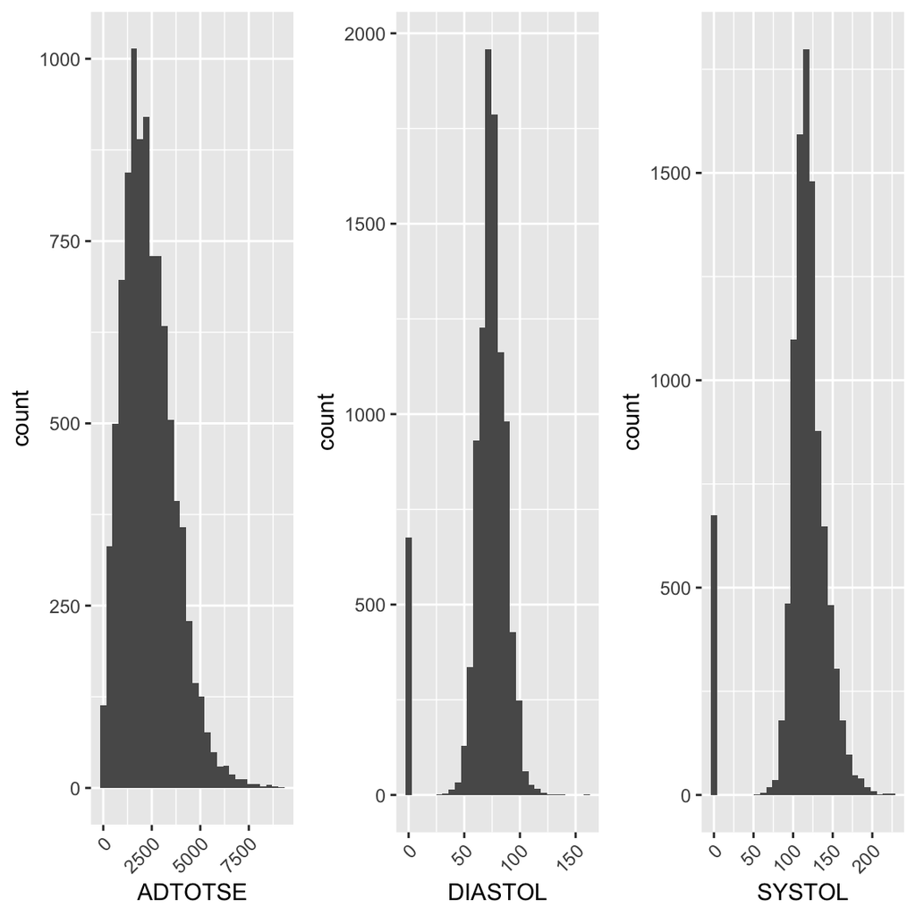

```r
n_tot = proc_biom %>%
    select(ADTOTSE) %>%
    nrow()
adtotse_prop = (proc_biom %>%
    filter(ADTOTSE == 0) %>%
    nrow())/n_tot * 100
adtotse_hist = ggplot(data = proc_biom) + geom_histogram(mapping = aes(x = ADTOTSE)) +
    theme(axis.text.x = element_text(angle = 45, hjust = 1))

n_tot = proc_biom %>%
    select(DIASTOL) %>%
    nrow()
diastol_prop = (proc_biom %>%
    filter(DIASTOL == 0) %>%
    nrow())/n_tot * 100
diastol_hist = ggplot(data = proc_biom) + geom_histogram(mapping = aes(x = DIASTOL)) +
    theme(axis.text.x = element_text(angle = 45, hjust = 1))

n_tot = proc_biom %>%
    select(SYSTOL) %>%
    nrow()
systol_prop = (proc_biom %>%
    filter(SYSTOL == 0) %>%
    nrow())/n_tot * 100
systol_hist = ggplot(data = proc_biom) + geom_histogram(mapping = aes(x = SYSTOL)) +
    theme(axis.text.x = element_text(angle = 45, hjust = 1))

grid.arrange(adtotse_hist, diastol_hist, systol_hist, ncol = 3)
```

```r
proc_biom = proc_biom %>%
    mutate(SYSTOL = case_when(SYSTOL == 0 ~ as.numeric(NA), TRUE ~ SYSTOL))


proc_biom = proc_biom %>%
    mutate(DIASTOL = case_when(DIASTOL == 0 ~ as.numeric(NA), TRUE ~ DIASTOL))


proc_biom = proc_biom %>%
    mutate(SYSTOL = case_when(SYSTOL == 0 ~ as.numeric(NA), TRUE ~ SYSTOL))
```

Click the next tab to see the next subsection on **low variance variables**

## low variances variables

As we are either dealing with numerical variables or categorical variables, we have to use different criteria based on the type of the variable we are dealing with.

- For numeric variables, we will use a more heuristic way. That is, we first begin by standardizing the data (taking away the mean and dividing by the standard deviation) then observing a boxplot of our variables. For relatively thin boxplots the corresponding variable will be discarded.
- For categorical variables if one particular level accounts for more than 85% of the observations for that variable **and** the other variables are approximately at the 10% margin (or less) then we consider that variable to have low variance

### Low variance numeric variables

By observing the numeric variables we see that two variables `EXLWMBC` and `EXLWVBC` were noteworthy for having low variance. As we can observe by their corresponding boxplots:

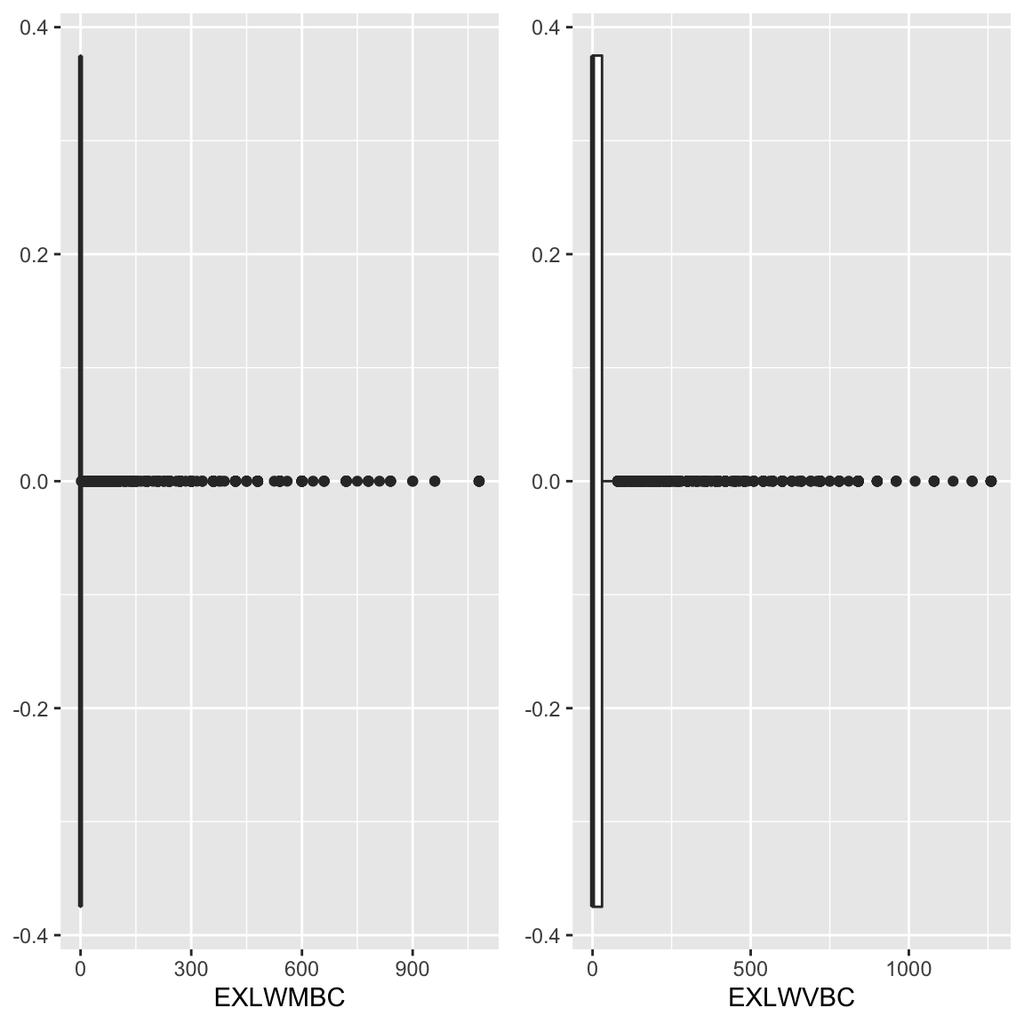

```r
exlwmbc_box = ggplot(data = proc_biom) + geom_boxplot(mapping = aes(x = EXLWMBC))

exlwvbc_box = ggplot(data = proc_biom) + geom_boxplot(mapping = aes(x = EXLWVBC))

grid.arrange(exlwmbc_box, exlwvbc_box, ncol = 2)
```

```r
# uncomment this to see a histogram of all the continuous variables

# DELETE numeric_names = types_biom %>% filter(variable_type == 'continuous')
# %>% select(variable_name) %>% pull() for (i in 1:length(numeric_names)) {
# name = numeric_names[i] dat = proc_biom %>% select((!!sym(name))) %>% pull()
# std_dat = (dat - mean(dat, na.rm = TRUE))/sd(dat, na.rm = TRUE) hist(std_dat,
# main = name) boxplot(std_dat, main = name) } numeric_names = types_biom %>%
# filter(variable_type == 'continuous') %>% select(variable_name) %>% pull()
# for (i in 1:length(numeric_names)) { name = numeric_names[i]
# print(ggplot(data = proc_biom) + geom_boxplot(mapping = aes(x =
# (!!sym(name))))) }
```

```r
# DELETE numeric_names = types_biom %>% filter(variable_type == 'continuous')
# %>% select(variable_name) %>% pull() for (i in 1:length(numeric_names)) {
# name = numeric_names[i] dat = proc_biom %>% select((!!sym(name))) %>% pull()
# print(paste(paste('-----', name, sep = ' '), '-----', sep = ' '))
# print(paste('dat:', as.character(IQR(dat, na.rm = TRUE)), sep = ' '))
# print(paste('median:', as.character(median(dat, na.rm = TRUE)), sep = ' '))
# print(IQR(dat, na.rm = TRUE)/median(dat, na.rm = TRUE)) }
```

Click the next tab to see the next part on **low variance categorical variables**

### Low variance categorical variables

To analyse the low variance categorical variables, we do this by comparing the proportions of each level of a given categorical variable. We define a categorical variable to have low variance if:

1. One level contains 85 (or more) percent of the observations.
2. The other levels of the categorical variable are below a 10 percent threshold.

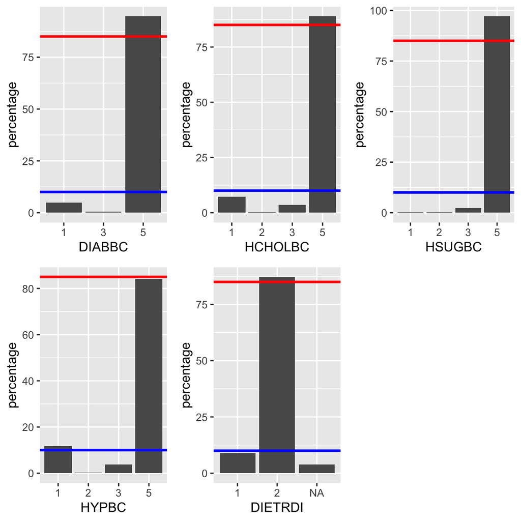

```r
categorical_names = types_biom %>%
    filter(variable_type == "categorical") %>%
    select(variable_name) %>%
    pull()
categorical_names = c("DIABBC", "HCHOLBC", "HSUGBC", "HYPBC", "DIETRDI")

diabbc_bar = ggplot(data = proc_biom, mapping = aes(x = DIABBC)) + geom_bar(mapping = aes(y = (..count..)/sum(..count..) *
    100)) + geom_hline(yintercept = 10, color = "blue", size = 1) + geom_hline(yintercept = 85,
    color = "red", size = 1) + ylab("percentage") + xlab("DIABBC")


hcholbc_bar = ggplot(data = proc_biom, mapping = aes(x = HCHOLBC)) + geom_bar(mapping = aes(y = (..count..)/sum(..count..) *
    100)) + geom_hline(yintercept = 10, color = "blue", size = 1) + geom_hline(yintercept = 85,
    color = "red", size = 1) + ylab("percentage") + xlab("HCHOLBC")


hsugbc_bar = ggplot(data = proc_biom, mapping = aes(x = HSUGBC)) + geom_bar(mapping = aes(y = (..count..)/sum(..count..) *
    100)) + geom_hline(yintercept = 10, color = "blue", size = 1) + geom_hline(yintercept = 85,
    color = "red", size = 1) + ylab("percentage") + xlab("HSUGBC")


hypbc_bar = ggplot(data = proc_biom, mapping = aes(x = HYPBC)) + geom_bar(mapping = aes(y = (..count..)/sum(..count..) *
    100)) + geom_hline(yintercept = 10, color = "blue", size = 1) + geom_hline(yintercept = 85,
    color = "red", size = 1) + ylab("percentage") + xlab("HYPBC")


dietrdi_bar = ggplot(data = proc_biom, mapping = aes(x = DIETRDI)) + geom_bar(mapping = aes(y = (..count..)/sum(..count..) *
    100)) + geom_hline(yintercept = 10, color = "blue", size = 1) + geom_hline(yintercept = 85,
    color = "red", size = 1) + ylab("percentage") + xlab("DIETRDI")


grid.arrange(diabbc_bar, hcholbc_bar, hsugbc_bar, hypbc_bar, dietrdi_bar, ncol = 3,
    nrow = 2)
```

Click the next to see that we dropped the low variance variables in **dropping low variance variables**

### Dropping low variance variables

We now just make an intentional note that after looking at the continuous and categorical variables with low variance, we will now drop them from the data set as they contribute minimal information to it. The variables we drop are:

```r
to_drop = c("EXLWMBC", "EXLWVBC", "DIABBC", "HCHOLBC", "HSUGBC", "HYPBC", "DIETRDI")
new_proc_biom = proc_biom %>%
    select(-EXLWMBC, -EXLWVBC, -DIABBC, -HCHOLBC, -HSUGBC, -HYPBC, -DIETRDI)
new_dict_biom = dict_biom %>%
    filter(!(variable_name %in% to_drop))
new_types_biom = types_biom %>%
    filter(!(variable_name %in% to_drop))
```

click the next tab to see the next subsection on **mismatches between the data and the data dictionary**

## Mismatches between data and data dictionary

- For the exercise variables (`EXLWTBC`, `EXLWMBC` and `EXLWVBC`) we needed to coerce the type back into a numeric value as that is what the data dictionary records it as.
- For the variable `SF2SA1QN` there is strong evidence that there is an error in the data dictionary. While the data dictionary states that the levels of this variable are split up into deciles, only the values 1-5 show up (denoting quintiles, which is supported by the [Australian Bureau of Statistics](https://www.abs.gov.au/ausstats/abs@.nsf/Lookup/15B5F6B85000EE97CA257B8D00229EA3?opendocument)). We can see this from the two tables below:

```r
freq_sf2sa1qn = new_proc_biom %>%
    select(SF2SA1QN) %>%
    pull() %>%
    table() %>%
    as.data.frame()
colnames(freq_sf2sa1qn) = c("SF2SA1QN Levels", "Frequency")
freq_sf2sa1qn_data_table = DT::datatable(freq_sf2sa1qn, rownames = FALSE, options = list(columnDefs = list(list(className = "dt-center",
    targets = 0:1))))
desc_sf2sa1qn = new_dict_biom %>%
    filter(variable_name == "SF2SA1QN") %>%
    select(-extra) %>%
    DT::datatable(., rownames = FALSE, options = list(columnDefs = list(list(className = "dt-center",
        targets = 0:1)), pageLength = 5))
```

```r
freq_sf2sa1qn_data_table
```

| SF2SA1QN Levels | Frequency |
| --- | --- |
| 1 | 2238 |
| 2 | 2464 |
| 3 | 2432 |
| 4 | 2177 |
| 5 | 2842 |

Figure 4: Frequency table for SF2SA1QN

```r
desc_sf2sa1qn
```

| variable_name | description |
| --- | --- |
| SF2SA1QN | SEIFA - Index of Relative Socio-Economic Disadvantage |
| SF2SA1QN | 0. Not applicable |
| SF2SA1QN | 1. Decile 1 (lowest) |
| SF2SA1QN | 2. Decile 2 |
| SF2SA1QN | 3. Decile 3 |
| SF2SA1QN | 4. Decile 4 |
| SF2SA1QN | 5. Decile 5 |
| SF2SA1QN | 6. Decile 6 |
| SF2SA1QN | 7. Decile 7 |
| SF2SA1QN | 8. Decile 8 |

[output cut: 3 more lines]

Figure 5: Data dictionary for SF2SA1QN

- For the variable `GGTNTR` there are 8022 observations which correspond to a level of 0. However, in the data dictionary there is no definition for a level corresponding to 0. We can see this from the two tables below:

```r
freq_ggtntr = new_proc_biom %>%
    select(GGTNTR) %>%
    pull() %>%
    table() %>%
    as.data.frame()
colnames(freq_ggtntr) = c("GGTNTR Levels", "Frequency")
freq_ggtntr_data_table = DT::datatable(freq_ggtntr, rownames = FALSE, options = list(columnDefs = list(list(className = "dt-center",
    targets = 0:1))))
desc_ggtntr = new_dict_biom %>%
    filter(variable_name == "GGTNTR") %>%
    select(-extra) %>%
    DT::datatable(., rownames = FALSE, options = list(columnDefs = list(list(className = "dt-center",
        targets = 0:1)), pageLength = 5))
```

```r
freq_ggtntr_data_table
```

| GGTNTR Levels | Frequency |
| --- | --- |
| 0 | 8022 |
| 1 | 3492 |
| 2 | 557 |
| 8 | 0 |

Figure 6: Frequency table for GGTNTR

```r
desc_ggtntr
```

| variable_name | description |
| --- | --- |
| GGTNTR | Gamma glutamyl transferase (GGT) status (U/L) |
| GGTNTR | 1. Normal GGT |
| GGTNTR | 2. Abnormal GGT |
| GGTNTR | 8. Not reported |

Figure 7: Data dictionary for GGTNTR

Scroll down to the next section to see how we addresses **missing values**

# Missing Values

## Visualising the data’s missingness

We firstly begin this section by visualizing the the patterns of missing-ness:

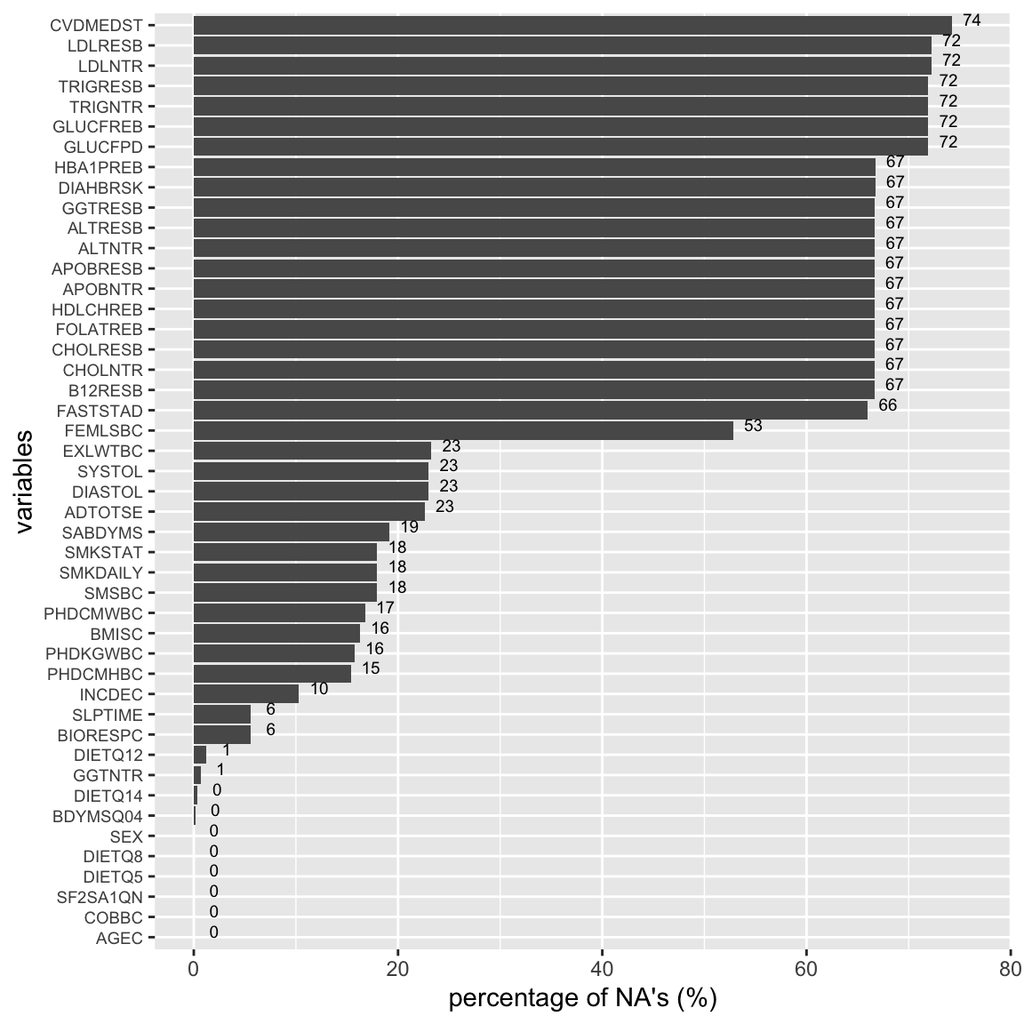

```r
num_na = function(vec, n) {
    sum(is.na(vec))/n * 100
}
save_names = colnames(new_proc_biom %>%
    select(-ABSPID))
missingness_df = new_proc_biom %>%
    select(-ABSPID) %>%
    summarize(across(everything(), list(na = ~num_na(., nrow(new_proc_biom)))))
missingness_df[2, ] = 100 - missingness_df[1, ]
colnames(missingness_df) = save_names
rownames(missingness_df) = c("na", "not_na")

save_names = colnames(missingness_df)
t_miss_df = transpose(missingness_df)
t_miss_df[, 3] = save_names
colnames(t_miss_df) = c("na", "not_na", "names")
t_miss_df = t_miss_df %>%
    arrange(na)
t_miss_df$names = factor(t_miss_df$names, levels = t_miss_df$names)

ggplot(data = t_miss_df, aes(x = names, y = na)) + geom_bar(stat = "identity") +
    geom_text(aes(label = round(na, 0), y = na + 2), position = position_dodge(0.9),
        size = 2.5, vjust = 0) + coord_flip() + theme(axis.text.y = element_text(size = 7)) +
    ylab("percentage of NA's (%)") + xlab("variables")
```

## A summary of the data’s missingness

From the following table, we can see the approximate percentage of missingness occurring in each of the variables (note that in the following data table it would be easier to type in the variable you want to search for).

```r
t_miss_df$names = as.character(t_miss_df$names)
t_miss_df = t_miss_df %>%
    arrange(names)
data_missingness_table = t_miss_df %>%
    mutate(`variable name` = names, `NA percentage` = round(na, 2)) %>%
    select("variable name", "NA percentage")


DT::datatable(data_missingness_table, rownames = FALSE, options = list(columnDefs = list(list(className = "dt-center",
    targets = 0:1))))
```

| variable name | NA percentage |
| --- | --- |
| ADTOTSE | 22.63 |
| AGEC | 0 |
| ALTNTR | 66.68 |
| ALTRESB | 66.68 |
| APOBNTR | 66.66 |
| APOBRESB | 66.66 |
| B12RESB | 66.65 |
| BDYMSQ04 | 0.13 |
| BIORESPC | 5.55 |
| BMISC | 16.25 |

[output cut: 36 more lines]

Figure 8: This table shows the variables in our data frame and the how much data is missing from each variable as a percentage

This summary is heightened by the bar chart in the previous tabbed section

## Removing missingness from data set

We deal with the `NA` values in steps:

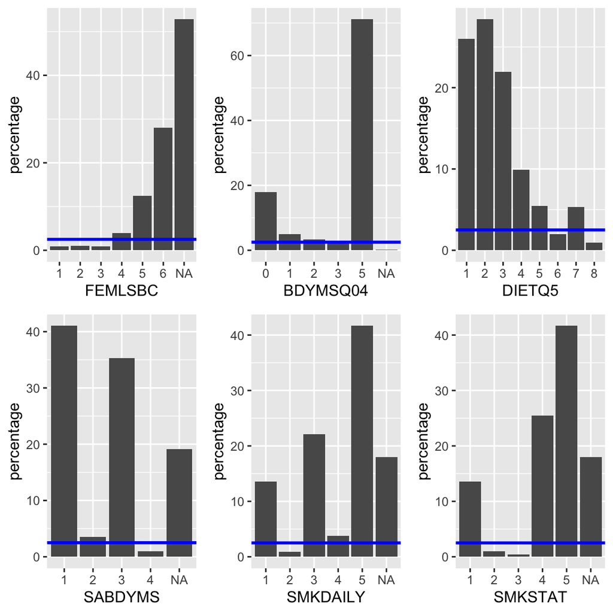

```r
# 1. **Variables with missingness between 72% to 74%**: `CVDMEDST`, `LDLRESB`,
# `LDLNTR`, `TRIGRESB`, `TRIGNTR`, `GLUCFREB` and `GLUCFPD` (7 variables) 2.
# **Variables with missingness between 53% to 67%**: `HBA1PREB`, `DIAHBRSK`,
# `GGTRESB`, `ALTRESB`, `ALTNTR`, `APOBRESB`, `APOBNTR`, `HDLCHREB`,
# `FOLATREB`, `CHOLRESB`, `CHOLNTR`, `B12RESB` and `FASTSTAD` (13 variables)

to_drop = c("CVDMEDST", "LDLRESB", "LDLNTR", "TRIGRESB", "TRIGNTR", "GLUCFREB", "GLUCFPD",
    "HBA1PREB", "DIAHBRSK", "GGTRESB", "ALTRESB", "ALTNTR", "APOBRESB", "APOBNTR",
    "HDLCHREB", "FOLATREB", "CHOLRESB", "CHOLNTR", "B12RESB", "FASTSTAD")

new_proc_biom = new_proc_biom %>%
    select(-CVDMEDST, -LDLRESB, -LDLNTR, -TRIGRESB, -TRIGNTR, -GLUCFREB, -GLUCFPD,
        -HBA1PREB, -DIAHBRSK, -GGTRESB, -ALTRESB, -ALTNTR, -APOBRESB, -APOBNTR, -HDLCHREB,
        -FOLATREB, -CHOLRESB, -CHOLNTR, -B12RESB, -FASTSTAD)

new_dict_biom = new_dict_biom %>%
    filter(!(variable_name %in% to_drop))
new_types_biom = new_types_biom %>%
    filter(!(variable_name %in% to_drop))


femlsbc_bar = ggplot(data = new_proc_biom, mapping = aes(x = FEMLSBC)) + geom_bar(mapping = aes(y = (..count..)/sum(..count..) *
    100)) + geom_hline(yintercept = 2.5, color = "blue", size = 1) + ylab("percentage") +
    xlab("FEMLSBC")


bdymsq04_bar = ggplot(data = new_proc_biom, mapping = aes(x = BDYMSQ04)) + geom_bar(mapping = aes(y = (..count..)/sum(..count..) *
    100)) + geom_hline(yintercept = 2.5, color = "blue", size = 1) + ylab("percentage") +
    xlab("BDYMSQ04")

dietq5_bar = ggplot(data = new_proc_biom, mapping = aes(x = DIETQ5)) + geom_bar(mapping = aes(y = (..count..)/sum(..count..) *
    100)) + geom_hline(yintercept = 2.5, color = "blue", size = 1) + ylab("percentage") +
    xlab("DIETQ5")

sabdyms_bar = ggplot(data = new_proc_biom, mapping = aes(x = SABDYMS)) + geom_bar(mapping = aes(y = (..count..)/sum(..count..) *
    100)) + geom_hline(yintercept = 2.5, color = "blue", size = 1) + ylab("percentage") +
    xlab("SABDYMS")

smkdaily_bar = ggplot(data = new_proc_biom, mapping = aes(x = SMKDAILY)) + geom_bar(mapping = aes(y = (..count..)/sum(..count..) *
    100)) + geom_hline(yintercept = 2.5, color = "blue", size = 1) + ylab("percentage") +
    xlab("SMKDAILY")

smkstat_bar = ggplot(data = new_proc_biom, mapping = aes(x = SMKSTAT)) + geom_bar(mapping = aes(y = (..count..)/sum(..count..) *
    100)) + geom_hline(yintercept = 2.5, color = "blue", size = 1) + ylab("percentage") +
    xlab("SMKSTAT")

grid.arrange(femlsbc_bar, bdymsq04_bar, dietq5_bar, sabdyms_bar, smkdaily_bar, smkstat_bar,
    ncol = 3, nrow = 2)
```

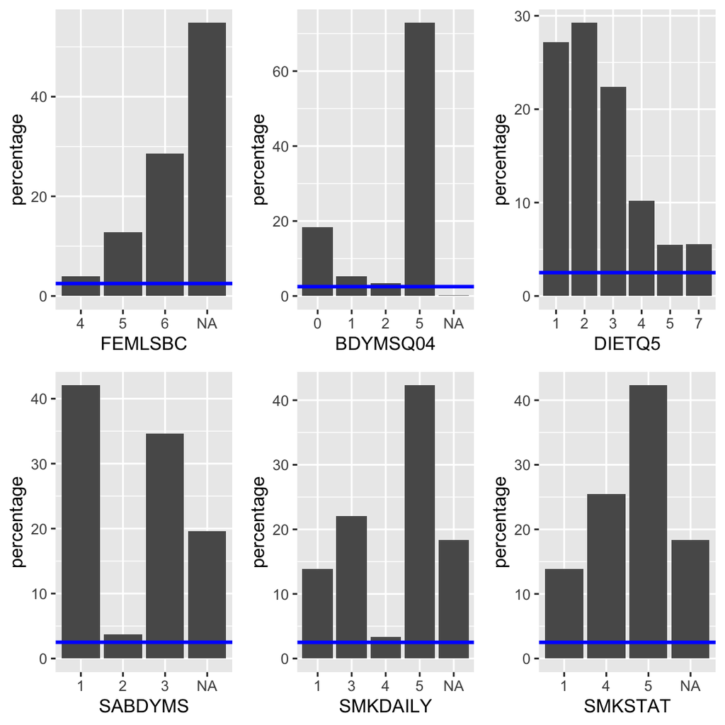

```r
new_proc_biom = new_proc_biom %>%
    filter(!(FEMLSBC %in% c(1, 2, 3))) %>%
    filter(!(BDYMSQ04 %in% c(3))) %>%
    filter(!(DIETQ5 %in% c(6, 8))) %>%
    filter(!(SABDYMS %in% c(4))) %>%
    filter(!(SMKDAILY %in% c(2))) %>%
    filter(!(SMKSTAT %in% c(2, 3)))

femlsbc_bar = ggplot(data = new_proc_biom, mapping = aes(x = FEMLSBC)) + geom_bar(mapping = aes(y = (..count..)/sum(..count..) *
    100)) + geom_hline(yintercept = 2.5, color = "blue", size = 1) + ylab("percentage") +
    xlab("FEMLSBC")


bdymsq04_bar = ggplot(data = new_proc_biom, mapping = aes(x = BDYMSQ04)) + geom_bar(mapping = aes(y = (..count..)/sum(..count..) *
    100)) + geom_hline(yintercept = 2.5, color = "blue", size = 1) + ylab("percentage") +
    xlab("BDYMSQ04")

dietq5_bar = ggplot(data = new_proc_biom, mapping = aes(x = DIETQ5)) + geom_bar(mapping = aes(y = (..count..)/sum(..count..) *
    100)) + geom_hline(yintercept = 2.5, color = "blue", size = 1) + ylab("percentage") +
    xlab("DIETQ5")

sabdyms_bar = ggplot(data = new_proc_biom, mapping = aes(x = SABDYMS)) + geom_bar(mapping = aes(y = (..count..)/sum(..count..) *
    100)) + geom_hline(yintercept = 2.5, color = "blue", size = 1) + ylab("percentage") +
    xlab("SABDYMS")

smkdaily_bar = ggplot(data = new_proc_biom, mapping = aes(x = SMKDAILY)) + geom_bar(mapping = aes(y = (..count..)/sum(..count..) *
    100)) + geom_hline(yintercept = 2.5, color = "blue", size = 1) + ylab("percentage") +
    xlab("SMKDAILY")

smkstat_bar = ggplot(data = new_proc_biom, mapping = aes(x = SMKSTAT)) + geom_bar(mapping = aes(y = (..count..)/sum(..count..) *
    100)) + geom_hline(yintercept = 2.5, color = "blue", size = 1) + ylab("percentage") +
    xlab("SMKSTAT")

grid.arrange(femlsbc_bar, bdymsq04_bar, dietq5_bar, sabdyms_bar, smkdaily_bar, smkstat_bar,
    ncol = 3, nrow = 2)
```

3. The final step is to remove any rows which have any missing data (for any variable) which we have done

```r
new_proc_biom = new_proc_biom[complete.cases(new_proc_biom), ]
```

# Saving our complete Data set

We have now saved our data sets into a `.Rdata` file. It is called `clean_data.Rdata` and it contains the data sets:

- `clean_biom` : This is the result of cleaning our technically correct data. More was said on this in the very beginning section in the executive summary
- `dict_biom` : This is the data dictionary with meanings as to all the levels of each variable
- `types_biom`: This is gives overlapping information to `dict_biom` however it provides the types of each of the variables in our data set.

```r
clean_biom = new_proc_biom
save(clean_biom, dict_biom, types_biom, file = "clean_data.Rdata")
```